# stringsAsFactors = HELLNO

Alejandra Urcelay

2018-11-15

Factors are a very useful type of variable in R, but they can also drive you nuts. Especially the “stealth factor” that you think of as character.

Can we soften some of their sharp edges?

## `fbind()`

Binding two factors via `fbind()`:

```r
library(foofactors)
a <- factor(c("character", "hits", "your", "eyeballs"))
b <- factor(c("but", "integer", "where it", "counts"))
```

Simply catenating two factors leads to a result that most don’t expect.

```r
c(a, b)
```

```
## [1] 1 3 4 2 1 3 4 2
```

The `fbind()` function glues two factors together and returns factor.

```r
fbind(a, b)
```

```
## [1] character hits      your      eyeballs  but       integer   where it
## [8] counts
## Levels: but character counts eyeballs hits integer where it your
```

Often we want a table of frequencies for the levels of a factor. The base `table()` function returns an object of class `table`, which can be inconvenient for downstream work. Processing with `as.data.frame()` can be helpful but it’s a bit clunky.

```r
set.seed(1234)
x <- factor(sample(letters[1:5], size = 100, replace = TRUE))
table(x)
```

```
## x
##  a  b  c  d  e
## 25 26 17 17 15
```

```r
as.data.frame(table(x))
```

```
##   x Freq
## 1 a   25
## 2 b   26
## 3 c   17
## 4 d   17
## 5 e   15
```

## `freq_out()`

The `freq_out()` function returns a frequency table as a well-named `tbl_df`:

```r
freq_out(x)
```

```
## # A tibble: 5 x 2
##   x         n
##   <fct> <int>
## 1 a        25
## 2 b        26
## 3 c        17
## 4 d        17
## 5 e        15
```

## `first_upper()`

The `first_upper()` function returns the same factor but with the first letter of each character value capitalized.

```r
months <- factor(c("january","february","march","april","may","june","july",
         "august","september","october","november","december"))
first_upper(months)
```

```
##  [1] January   February  March     April     May       June      July
##  [8] August    September October   November  December
## 12 Levels: April August December February January July June March ... September
```

## `subfactor()`

The `subfactor()` This function returns a factor with just the first three letters of each element.

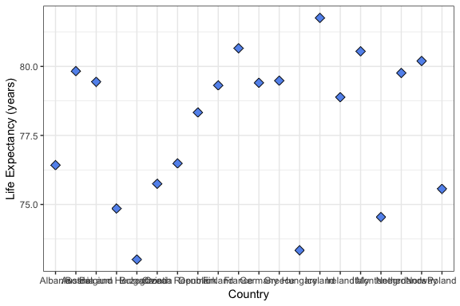

```r
library(tidyverse)
library(scales)
library(gapminder)
Euro <- gapminder %>%
  filter(year == 2007, continent == "Europe" ) %>%
  head(20)

Euro %>%
  ggplot(aes(x = country, y = lifeExp)) +
  geom_point(shape = 23, fill = 'cornflowerblue', size = 3) +
  guides(fill=F) +
  labs(x = "Country", y = "Life Expectancy (years)") +
  theme_bw()
```

And now lets see after applying the `subfactor()` function

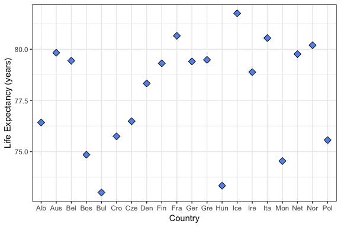

```r
Euro %>%
  ggplot(aes(x = subfactor(country), y = lifeExp)) +
  geom_point(shape = 23, fill = 'cornflowerblue', size = 3) +
  labs(x = "Country", y = "Life Expectancy (years)") +
  theme_bw()
```

## `factor_asis()`

The `factor_asis()` function encodes a vector as a factor with levels in the same order as they appear in the data instead of the alphabetical order.

```r
continents <- factor(c("Asia", "Europe", "Africa", "Americas", "Oceania"))
levels(continents)
```

```
## [1] "Africa"   "Americas" "Asia"     "Europe"   "Oceania"
```

```r
continents_asis <- factor_asis(c("Asia", "Europe", "Africa", "Americas", "Oceania"))
levels(continents_asis)
```

```
## [1] "Asia"     "Europe"   "Africa"   "Americas" "Oceania"
```

This function has the same effect when plotting. To demonstrate this, let’s look at a plot of the number of countries in each continent from the `gapminder` dataset without modification.

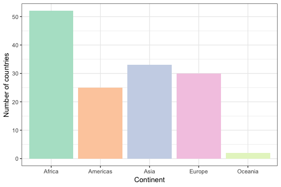

```r
gapminder %>%
  filter(year == 2007) %>%
  ggplot(aes(x = continent, fill = continent)) +
  scale_fill_brewer(palette = "Pastel2") +
  geom_bar() +
  guides(fill=F) +
  labs(x = "Continent", y = "Number of countries") +
  theme_bw()
```

And now the same plot using `factor_asis()`.

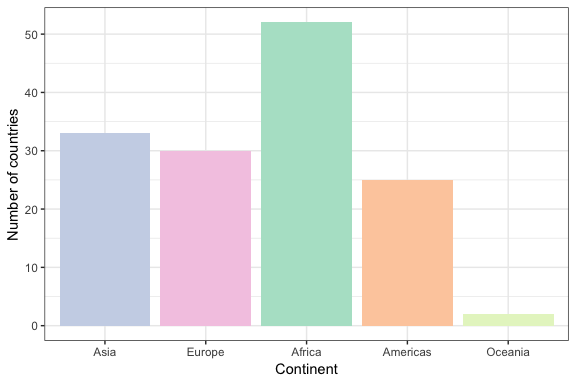

```r
gapminder %>%
  filter(year == 2007) %>%
  ggplot(aes(x = factor_asis(continent), fill = continent)) +
  scale_fill_brewer(palette = "Pastel2") +
  geom_bar() +
  guides(fill=F) +
  labs(x = "Continent", y = "Number of countries") +
  theme_bw()
```

As noted, the order of the continents corresponds to the order of appearance in the dataset.

## `reorder_desc()`

The `reorder_desc()` function reorders the levels of a factor in a descending order.

```r
alpha_continents <- factor(c("Africa", "Americas", "Asia", "Europe", "Oceania"))
alpha_continents
```

```
## [1] Africa   Americas Asia     Europe   Oceania
## Levels: Africa Americas Asia Europe Oceania
```

```r
reorder_desc(alpha_continents)
```

```
## [1] Africa   Americas Asia     Europe   Oceania
## attr(,"scores")
##   Africa Americas     Asia   Europe  Oceania
##       -1       -2       -3       -4       -5
## Levels: Oceania Europe Asia Americas Africa
```

This function mantains levels in a descending order even when plotting:

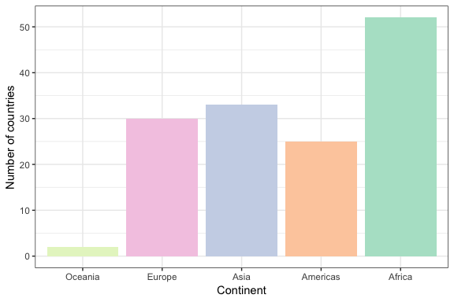

```r
gapminder %>%
  filter(year == 2007) %>%
  ggplot(aes(x = reorder_desc(continent), fill = continent)) +
  scale_fill_brewer(palette = "Pastel2") +
  geom_bar() +
  guides(fill=F) +
  labs(x = "Continent", y = "Number of countries") +
  theme_bw()
```

[output not shown]